# Can a Prophet Inspire Change?

An analysis of General Conference Talks

Images are used with permission from the Church of Jesus Christ of Latter-Day Saints  
Members of the Church of Jesus Christ of Latter-Day Saints believe their Prophet to be an inspired leader. In fact, the Prophet is the only leader with authority to make decisions for the church as a whole. Often Prophets for the Church of Jesus Christ of Latter-Day Saints have focuses and initiatives that are specific to their ministry. To what extent do Prophets inspire change today?

This analysis will seek to prove three significant changes in the culture of the Church of Jesus Christ each brought about by a different modern Prophet. Click the tabs below to view how President Hinckley changed the way the church talks about temples, how President Benson increased references to the Book of Mormon in General Conference, and how President Nelson has inspired more discussions on the “Gathering of Israel” than ever before!

#### Temples

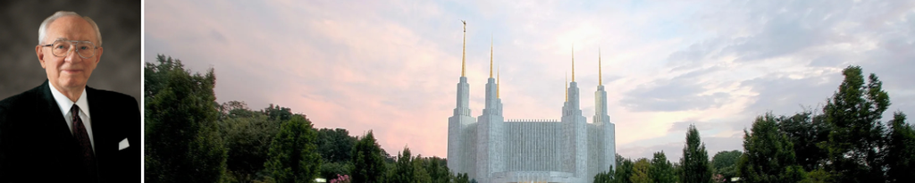

President Hinckley © By Intellectual Reserve, Inc. | Washington D.C. Temple by Neal Most  
*(“Temple”, “Temples”, “House of God”, “House of the Lord”)*

Temple construction has boomed since 1995. From 1995 to 2020 the world went from 47 to 168 in operation. This is an unprecedented increase!

Of temples President Hinckley said, *“We are determined, brethren, to take the temple to the people and afford them every opportunity for the very precious blessings that come of temple worship.”* [October 1997 Address](https://www.churchofjesuschrist.org/study/general-conference/1997/10/some-thoughts-on-temples-retention-of-converts-and-missionary-service)

During his time as Prophet nearly 80 temples were dedicated - an impressive number as when he was called to the position there were less than 50 in operation. Through the design and construction of smaller temples, and an increase in the rate at which temples were announced and built, President Hinckley introduced the church to a new age of temple availability that continues to this day.

This plot shows the number of temples in the world by year:

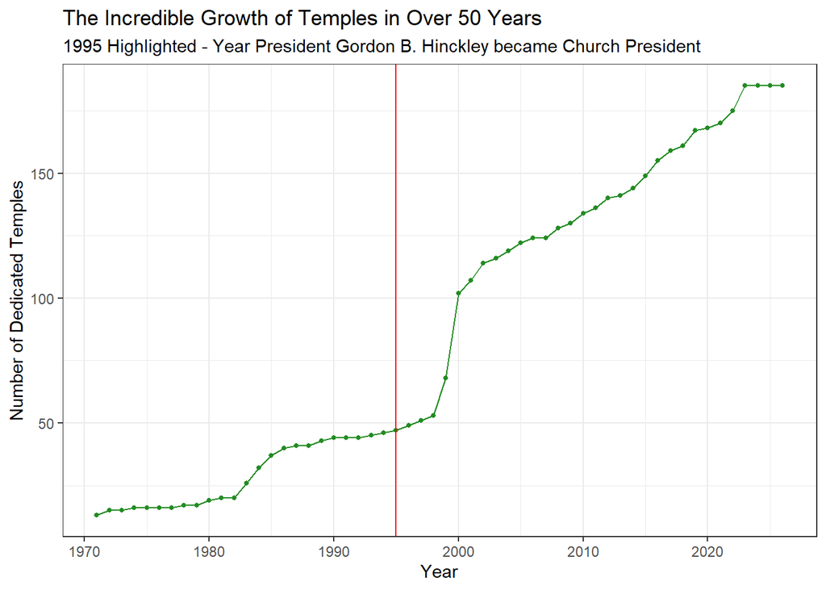

Clearly the number of temples in the world has increased, but has the culture of the church as a whole changed because of this focus? One way we can find out is by analyzing the number of references to temples in General Conference talks.

##### Scatter Plots

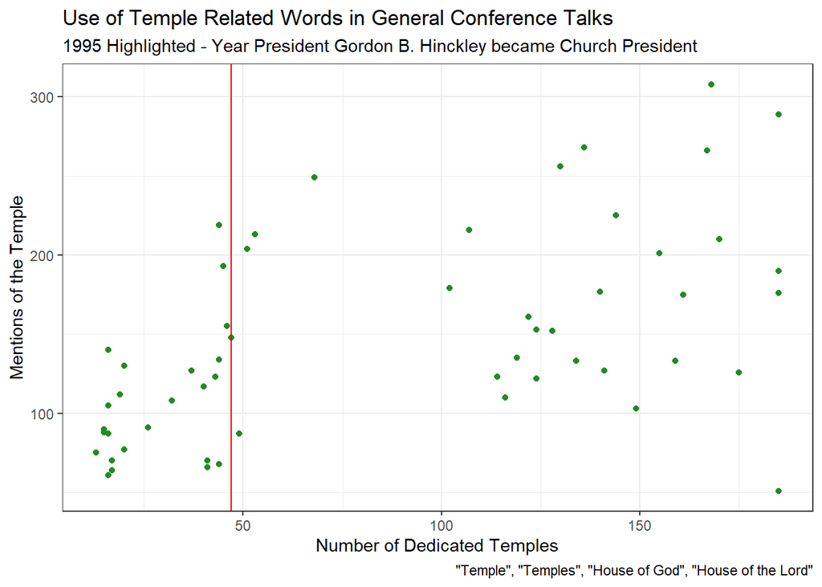

This time the phrases are shown in different colors.

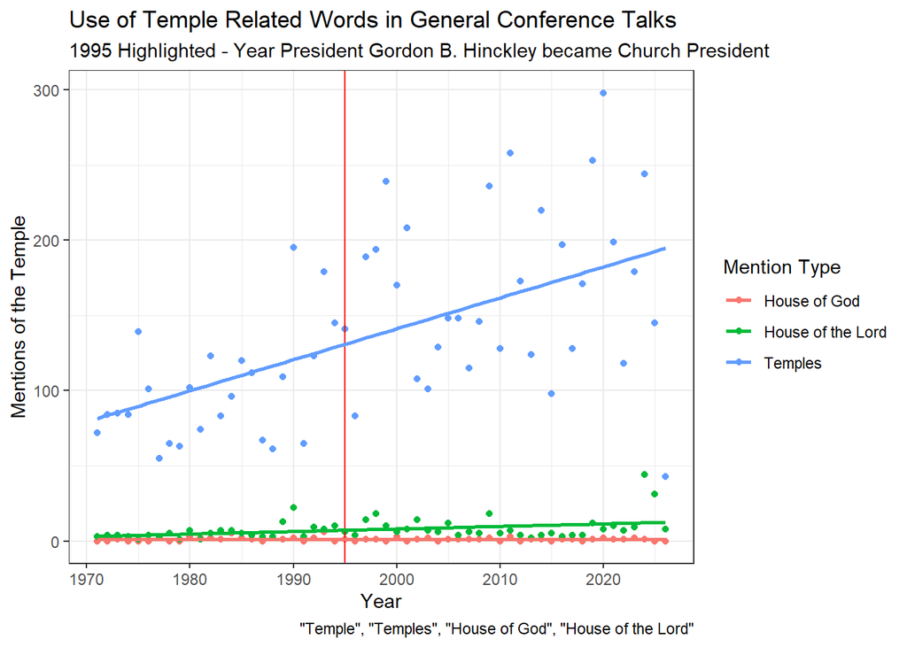

##### Box Plot

This boxplot shows that there is an increase in temple-related words between before President Hinckley was the prophet and our current Post-President Hinckley era. It seems temples are being talked about more now than they were before his sustaining.

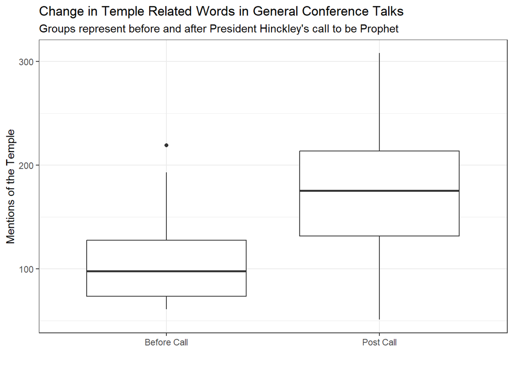

Numerical Summary:

| group | min | Q1 | median | Q3 | max | mean | sd | n |
| --- | --- | --- | --- | --- | --- | --- | --- | --- |
| Before Call | 61 | 73.75 | 98 | 127.8 | 219 | 107.1 | 40.92 | 24 |
| Post Call | 51 | 131.5 | 175.5 | 213.8 | 308 | 177.1 | 61.68 | 32 |

##### T Test

On top of that, based on the box plots of the previous tab, it is easy to conclude that Temples are mentioned more after President Hinckley’s call than before he was the prophet!

Welch Two Sample t-test: `total` by `group` (continued below)

| Test statistic | df | P value | Alternative hypothesis |
| --- | --- | --- | --- |
| -5.095 | 53.31 | 4.696e-06 * * * | two.sided |

| mean in group Before Call | mean in group Post Call |
| --- | --- |
| 107.1 | 177.1 |

##### Linear Model

This linear model table gives us information about the slope and intercepts of the line for each of the phrases we are tracking in General Conference talks. However, the Y-intercept is attempting to estimate the number of mentions of each phrase at the year 0. Because that statistic is not meaningful it should be ignored.

|  | Estimate | Std..Error | t.value | Pr…t.. |
| --- | --- | --- | --- | --- |
| **House of God - Y Int.** | 12.39 | 482.5 | 0.02569 | 0.9795 |
| **House of the Lord - Y Int.** | -343.7 | 682.4 | -0.5037 | 0.6151 |
| **Temples - Y Int.** | -3986 | 682.4 | -5.842 | 2.752e-08 |
| **House of God - Slope** | -0.005639 | 0.2414 | -0.02336 | 0.9814 |
| **House of the Lord - Slope** | 0.1754 | 0.3414 | 0.5136 | 0.6082 |
| **Temples - Slope** | 2.063 | 0.3414 | 6.043 | 1.006e-08 |

#### Book of Mormon

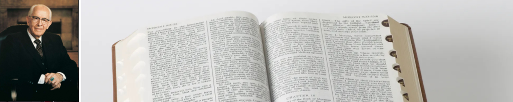

President Benson by Busath Photography © By Intellectual Reserve, Inc. | Scriptures © By Intellectual Reserve, Inc.  
*(“Book of Mormon”)*

1986 was a big year for the Book of Mormon. President Ezra Taft Benson delivered a General Conference talk instructing members to use the Book of Mormon in teachings.

How did this calling to action effect the number of quotes from the Book of Mormon in General Conference talks?

##### Scatter Plots

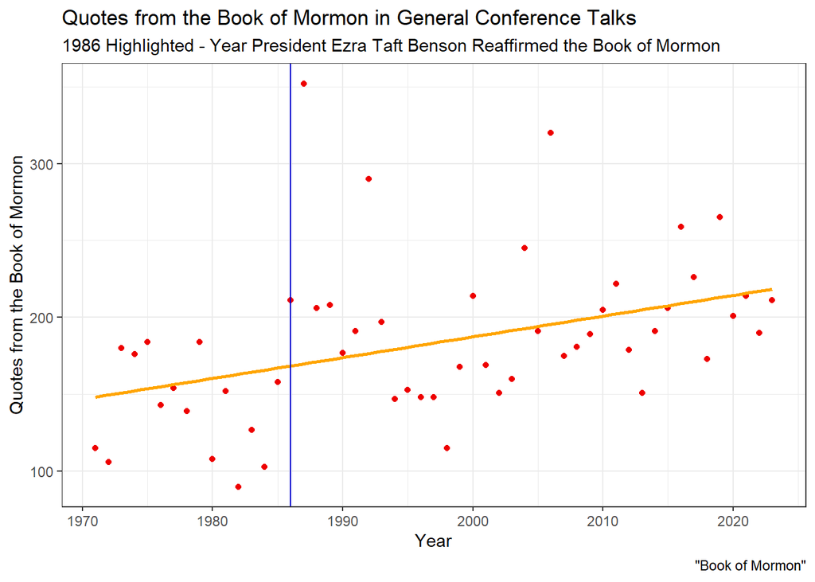

This plot represents the number of scriptures quoted from Book of Mormon verses within General Conference talks per year. Interestingly this plot seems to have a correlation with the previous, in which case it too has a positive change following the message from President Benson.

The following tabs will attempt to prove, statistically, that this positive change is significant.

##### Box Plot

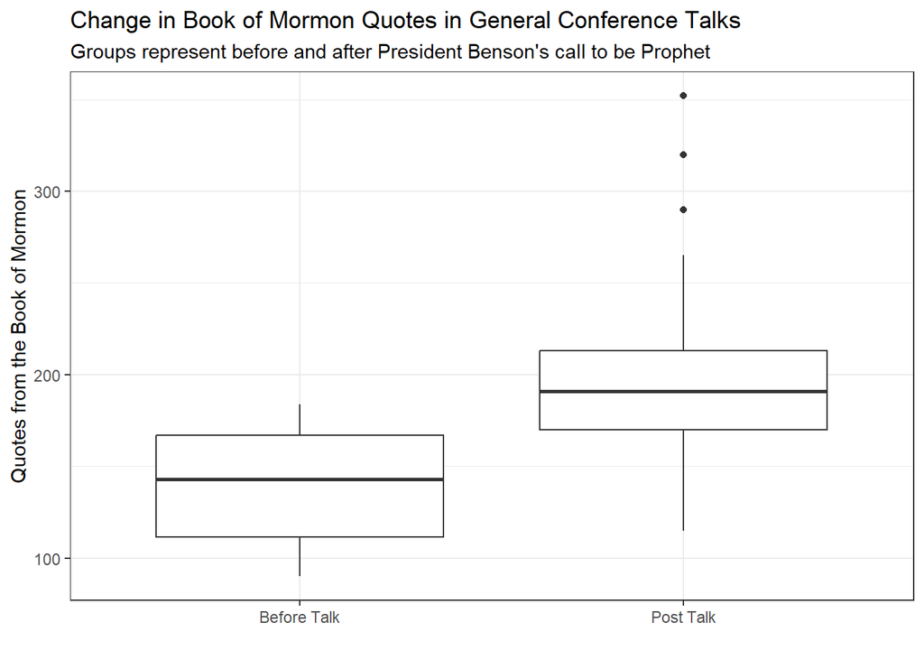

Numerical Summary:

| group | min | Q1 | median | Q3 | max | mean | sd | n |
| --- | --- | --- | --- | --- | --- | --- | --- | --- |
| Before Talk | 90 | 111.5 | 143 | 167 | 184 | 141.3 | 31.92 | 15 |
| Post Talk | 115 | 170 | 191 | 213.2 | 352 | 200 | 48.35 | 38 |

This table shows a large change in the number of Book of Mormon quotes represented in General Conference talks between the two groups. Before President Benson reaffirmed the Book of Mormon the typical year would see around `141.3` quotes from the Book of Mormon, with a max of `184` quotes in a year.

However, in contrast, in the years following the prophet’s message we typically see around `200` quotes from the Book of Mormon in a year, with some years seeing over 300 quotes -and a max of `352` in one year! The average has increased by 60 quotes per year and the maximum is nearly double the maximum from the previous group. This is an astounding change as well.

##### T Test

Welch Two Sample t-test: `total` by `group` (continued below)

| Test statistic | df | P value | Alternative hypothesis |
| --- | --- | --- | --- |
| -5.16 | 38.8 | 7.634e-06 * * * | two.sided |

| mean in group Before Talk | mean in group Post Talk |
| --- | --- |
| 141.3 | 200 |

This T Test is a statistical test meant to tell us if the means of both populations differ from each other. Because our result (`7.634e-06`) is smaller than the confidence interval of `95%` we can conclude the two means are significantly different.

From this result and the boxplots in the previous tab we can conclude that there are more quotes from the Book of Mormon in General Conference talks following the message from President Benson than before!

##### Linear Model

This linear model table gives us information about the slope and intercepts of the line for the number of Book of Mormon quotes over time. Like with the Temple mentions linear model, the Y-intercept is trying to estimate the number of Book of Mormon quotes in the year 0 which is not meaningful. Because of this it should be ignored.

|  | Estimate | Std. Error | t value | Pr(>\|t\|) |
| --- | --- | --- | --- | --- |
| **(Intercept)** | -2513 | 852.3 | -2.948 | 0.004812 |
| **talk_year** | 1.35 | 0.4268 | 3.163 | 0.002627 |

Fitting linear model: total ~ talk_year

| Observations | Residual Std. Error | $R^2$ | Adjusted $R^2$ |
| --- | --- | --- | --- |
| 53 | 47.53 | 0.164 | 0.1476 |

This table shows us that the slope of our linear model is `1.35`, a positive slope! This means that in our model the number of Book of Mormon quotes increased by 1.35 year over year. Our p-value (`0.002627`) is significant as well, meaning this positive slope in Book of Mormon quotes is a meaningful one. This is an important observation as it proves that quotes from the Book of Mormon has increased over time.

##### Bible Comparison

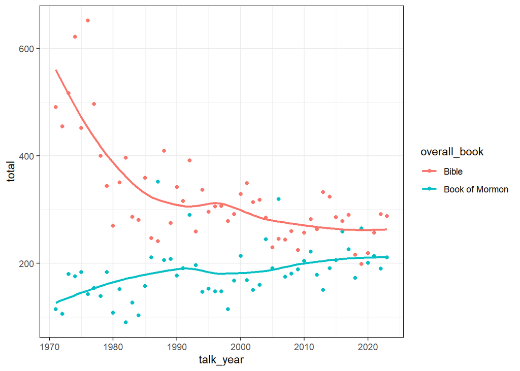

Is there a difference in boxplots Pre President Benson and Post President Benson?

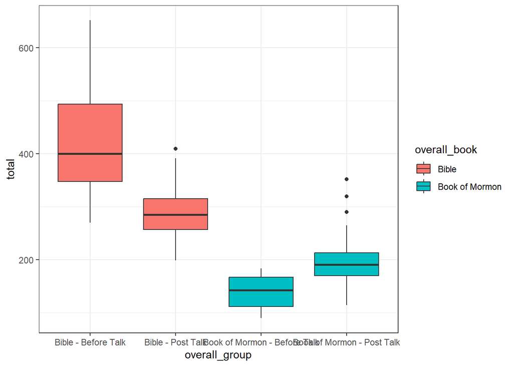

#### Gathering Israel

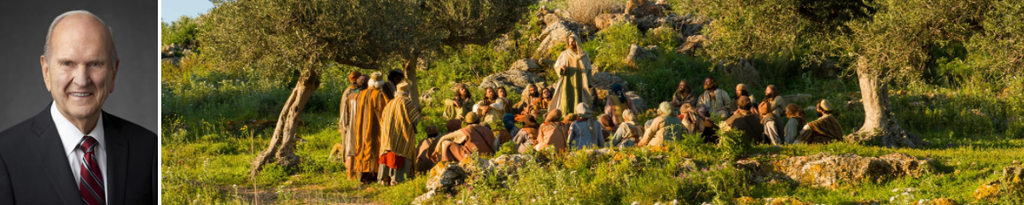

President Nelson © By Intellectual Reserve, Inc. | Jesus Teaching in Parables © By Intellectual Reserve, Inc.  
*(“Gathering Israel”, “Both Sides of the Veil”)*

The main focus of President Nelson’s ministry is, “Gathering Israel on both sides of the veil”. This focus includes missionary work, temple work, and each individual’s commitment to following the covenant path.

Has this focus permeated the church as a whole? Here we have conducted a simple word analysis to determine if phrases related to gathering Israel have increased.

##### Scatter Plots

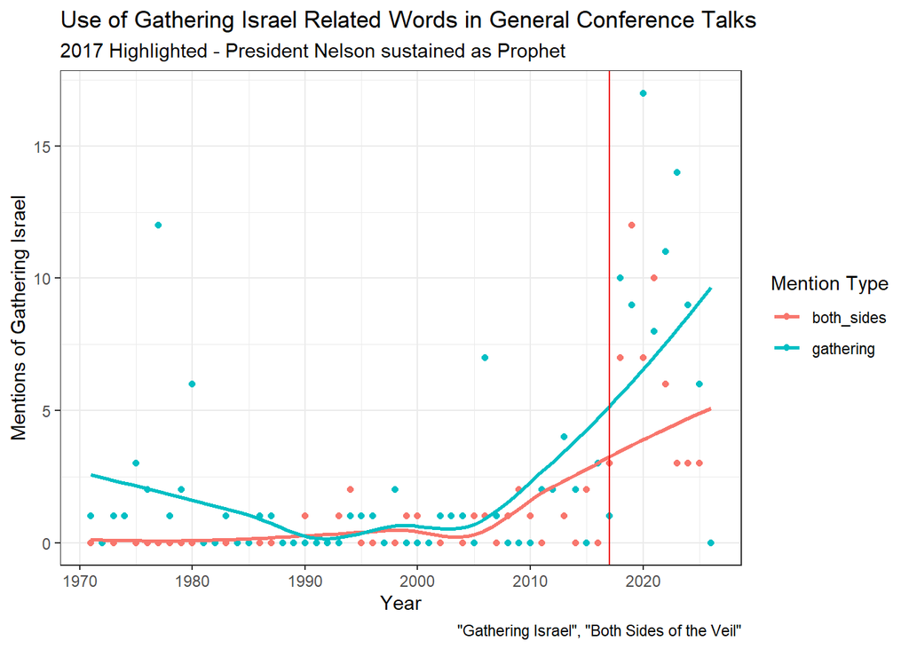

Our statistical models have shown that this difference is significant! Therefore, we can safely conclude that President Nelson’s focus on the gathering of Israel has increase the mentions of the gathering in general conference talks.

##### Box Plot

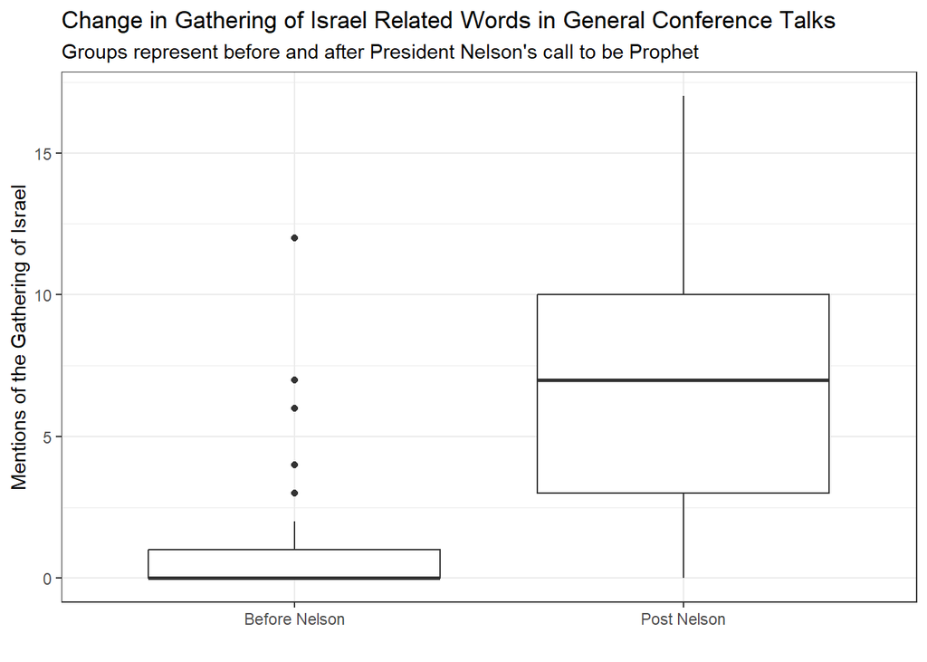

Numerical Summary:

| group | min | Q1 | median | Q3 | max | mean | sd | n |
| --- | --- | --- | --- | --- | --- | --- | --- | --- |
| Before Nelson | 0 | 0 | 0 | 1 | 12 | 0.8696 | 1.685 | 92 |
| Post Nelson | 0 | 3 | 7 | 10 | 17 | 6.95 | 4.685 | 20 |

This table shows an incredible change in mentions of the Gathering of Israel. Before President Nelson’s call to be the Prophet and President of the church it was common place to have no mention of the Gathering of Israel at all. In fact the average was `0.8696` mentions of the subject per year! The maximum number of mentions was `12` times in one year, with 11 of those mentions derived from a talk entitled, “[Come: Let Israel Build Zion](https://www.churchofjesuschrist.org/study/general-conference/1977/04/come-let-israel-build-zion)” by Elder Bruce R. McConkie.

##### T Test

Welch Two Sample t-test: `total` by `group` (continued below)

| Test statistic | df | P value | Alternative hypothesis |
| --- | --- | --- | --- |
| -5.725 | 20.08 | 1.311e-05 * * * | two.sided |

| mean in group Before Nelson | mean in group Post Nelson |
| --- | --- |
| 0.8696 | 6.95 |

### Conclusion

Based on these conclusions, and I’m sure many other examples outside of this analysis, we can determine that Prophets do indeed inspire change within the church.

#### Other Articles: